# What has been done

This section shows the main steps that have been applied to pre-process the raw data.

## aCDOM spectra

- The CDOM spectra were modeled according to the information in Babin 2003.
  - `acdom` spectra were re-fitted using the complete data (i.e. between 350-500 nm).
- Average background values calculated between 683-687 nm.
- Some files were in binary format, so I could not open them (ex.: `C2001000.YSA`).
- Some spectra start at 300 nm while others at 350 nm.
- Calculated the correlation between the measured and the fitted values. Fits with R2 than 0.99 were removed from the data.
- Exported the complete spectra (350-700 nm): both the raw and the modeled data.

## Phytoplankton and non-algal absorption

- Original data had average background calculated between 745 and 750 nm. This average background have been re-added to the spectra. Thereafter, a new averaged background values were calculated between 746 and 750 nm and subtracted from the spectra.

## Irradiance

- There were negative values in the irradiance data (`Ed`, `Eu`, `Kd`, `Ku`). I have cleaned the data by setting these negative values to `NA`.
  - **To validate**

## Other stuff

- Extracted extra variables (`DOC`, `AQY`) from Massimo 2000.

# Visualizations

Just some graphs to visualize the data. *Note that the same color palette will be used to represent the areas in all graphics.*

## Geographical map

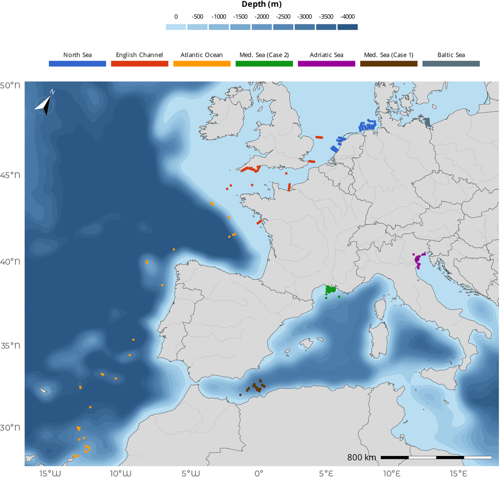

## Available variables

Just an overview of the available variables (excluding radiometric measurements).

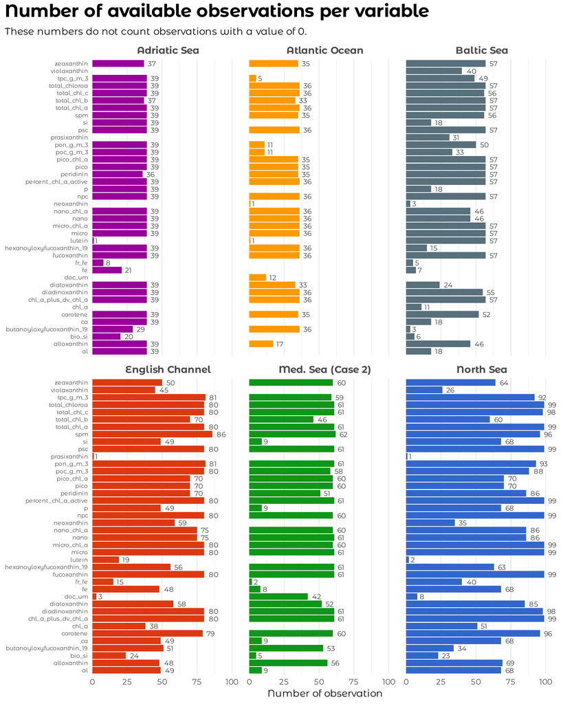

## Absorption measurements

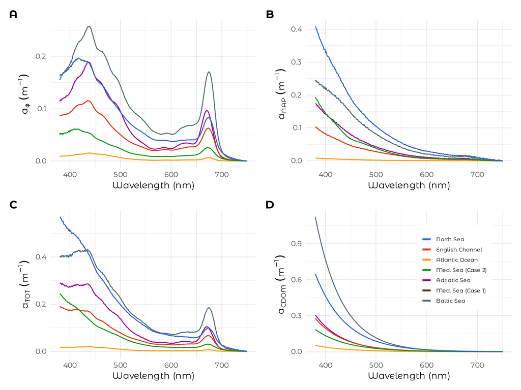

Comparing `acdom443` for the different areas shows that there is a clear open to coastal gradient.

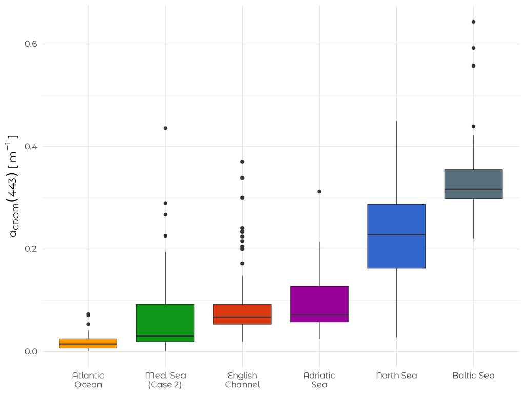

We can see that the `DOC` follows the same pattern as `acdom443`.

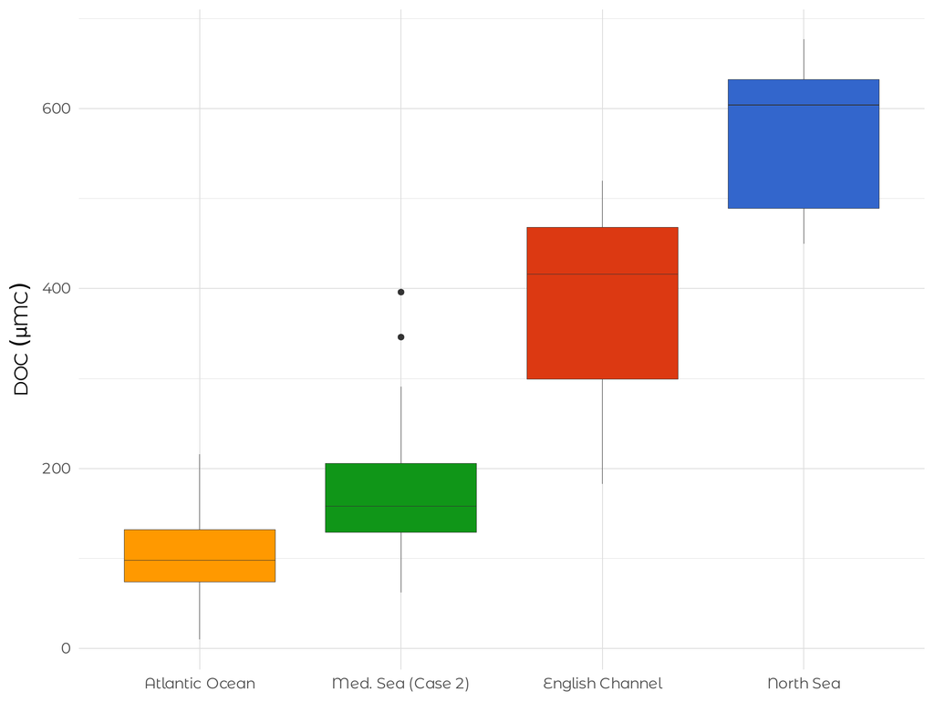

We can also use scatterplots to further explore the relationships among variables.

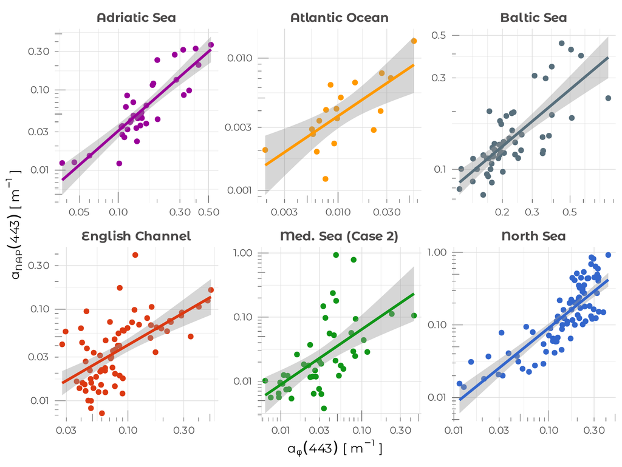

Relationships between some pigments.

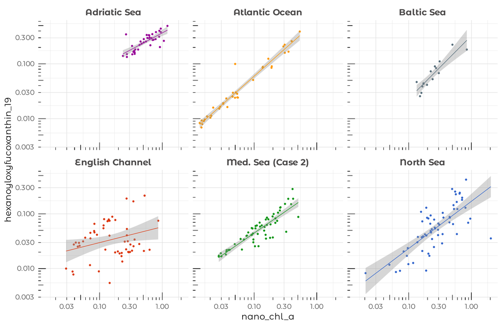

# TODOS

- There are two stations without geographical coordinates: `C2001000`, `C2002000`.
- Find a good way to flag the data:
  - For example, all `a_phy`, `a_nap`, `a_tot` spectra contain negative absorption values, but this does not mean they are bad spectra.
- There are a lot of nutrient parameters that have values of zero. Are they true zero or indicate missing values?
- Orientation of the paper
  - The data is a mix of temporal and spatial observations, so how should we present the data?
    - By `area`?

## Irradiance data

- `Eu` means that `Eu0-` was estimated (see with Marcel, I do not remember what it means).
- `Ed` is `Ed0-` calculated from `0.96 x ed0+`.
  - Change the name in the data files `ed` to `ed0-`.

## Reflectance

- There are negative values.

## AC9

- `a(715)` is always at 0.
- There are negative values.